# edmsyn package demo

Hoang-Trieu Trinh

30 August 2015

# **0. Load the package**

```r
library(edmsyn)
ALL.MODELS
```

```
##  [1] "exp"     "irt"     "poks"    "dina"    "dino"    "lin.avg" "nmf.con"
##  [8] "nmf.dis" "nmf.com" "bkt"
```

# **1. Class `context` and function `pars()`**

- An object of class `context` is a consistent list of all parameters from `ALL.MODELS`
- Get a `context` from function `pars()`

```r
p <- pars(students = 20, items = 20)
class(p)
```

```
## [1] "context"
```

```r
names(p)
```

```
##  [1] "init.vals"        "dis"              "dif"
##  [4] "abi"              "abi.mean"         "abi.sd"
##  [7] "st.exp"           "it.exp"           "items"
## [10] "concepts"         "students"         "state"
## [13] "po"               "or.t"             "or.f"
## [16] "student.var"      "avg.success"      "min.ntree"
## [19] "max.ntree"        "trans"            "min.depth"
## [22] "max.depth"        "density"          "min.it.per.tree"
## [25] "max.it.per.tree"  "alpha.c"          "alpha.p"
## [28] "p.min"            "slip"             "guess"
## [31] "per.item"         "order"            "Q"
## [34] "S"                "M"                "L"
## [37] "bkt.mod"          "S.st.var"         "S.con.exp"
## [40] "L.st.var"         "L.con.exp"        "skill.space.size"
## [43] "skill.space"      "skill.dist"       "concept.exp"
## [46] "bkt.slip"         "bkt.guess"        "time"
## [49] "bkt.slip.it.exp"  "bkt.slip.st.var"  "bkt.guess.it.exp"
## [52] "bkt.guess.st.var" "irt"              "exp"
## [55] "dina"             "dino"             "nmf.con"
## [58] "nmf.dis"          "nmf.com"          "lin.pes"
## [61] "lin.avg"          "poks"             "bkt"
```

```r
p$avg.success
```

```r
p
```

```
## Activated units in the context:
## [1] "init.vals" "items"     "students"
```

- Update `p` also by `pars()`

```r
p <- pars(p, concepts = 5)
p
```

```
## Activated units in the context:
## [1] "init.vals" "items"     "concepts"  "students"
```

- `p$init.vals` contains all the default values, so that if a `NULL` parameter is in need, it will load its value from `p$init.vals`

```r
names(p$init.vals)
```

```
##  [1] "student.var"      "avg.success"      "time"
##  [4] "S.st.var"         "L.st.var"         "bkt.slip.st.var"
##  [7] "bkt.guess.st.var" "min.ntree"        "min.depth"
## [10] "min.it.per.tree"  "per.item"         "bkt.mod"
## [13] "density"          "alpha.c"          "alpha.p"
## [16] "p.min"            "abi.mean"         "abi.sd"
## [19] "trans"
```

```r
p$init.vals$avg.success
```

```
## [1] 0.5
```

`pars()` always make sure that there is no conflicts in the context

```r
p <- pars(p, Q = matrix(1,30,5))
```

```
## Error in down.stream(new.pars): 'items' receives different values at once
```

This is useful because some kinds of conflict are not always clear

```r
#We know that avg.success == mean(st.exp) == mean(it.exp)
pars(st.exp = rep(0.3,100), it.exp = rep(0.2,20))
```

```
## Error in down.stream(new.pars): 'avg.success' receives different values at once
```

At this point, it is good to notice that there are two reasons why `avg.success` must stay `NULL` until needed instead of taking the default value 0.5 right when `pars()` is called:

- 0.5 may conflicts with some information the user input into `pars()`
- There is no reason why `avg.success` should be activated if the user is looking at a model that does not use `avg.success`

The benefit of introducing this class is mostly convenience.

- Useful when a user is working across many different models while considering some shared parameters.
- Useful when a user wants different type of generating data without having to use many separate functions.

# **2. Get a parameter from a `context` by `get.par()`**

```r
p$students
```

```
## [1] 20
```

```r
get.par("students", p)
```

```
## $value
## [1] 20
##
## $context
## Activated units in the context:
## [1] "init.vals" "items"     "concepts"  "students"
```

The advantage of `get.par()` is :

```r
p$M
```

```r
get.par("M",p)
```

```
## $value
##      [,1] [,2] [,3] [,4] [,5] [,6] [,7] [,8] [,9] [,10] [,11] [,12] [,13]
## [1,]    0    0    0    0    0    0    0    0    0     0     0     0     1
## [2,]    0    0    0    0    1    1    1    1    0     1     1     0     1
## [3,]    0    1    0    1    1    0    1    1    1     0     0     0     0
## [4,]    0    1    1    1    1    0    0    1    0     1     0     1     1
## [5,]    1    1    1    0    0    1    0    1    1     1     1     0     1
##      [,14] [,15] [,16] [,17] [,18] [,19] [,20]
## [1,]     0     0     0     0     0     0     0
## [2,]     0     1     0     0     0     1     1
## [3,]     1     0     1     0     1     1     0
## [4,]     1     1     1     0     0     0     0
## [5,]     1     1     1     1     1     0     1
##
## $context
## Activated units in the context:
## [1] "init.vals"   "items"       "concepts"    "students"    "M"
## [6] "concept.exp"
```

See the progress by option `progress = TRUE`

```r
get.par("M",p,progress = TRUE)
```

```
## Generate M from c("students", "concept.exp")
## Generate concept.exp from concepts
```

```
## $value
##      [,1] [,2] [,3] [,4] [,5] [,6] [,7] [,8] [,9] [,10] [,11] [,12] [,13]
## [1,]    1    1    1    1    1    1    1    0    1     1     1     1     1
## [2,]    0    0    0    0    0    0    0    0    0     0     0     0     0
## [3,]    0    0    0    1    0    1    0    0    0     1     1     0     0
## [4,]    0    1    1    0    1    1    0    1    1     0     0     1     0
## [5,]    0    0    0    0    1    1    0    1    0     0     0     1     1
##      [,14] [,15] [,16] [,17] [,18] [,19] [,20]
## [1,]     1     1     1     1     1     1     1
## [2,]     0     0     0     0     0     0     0
## [3,]     1     0     0     0     0     1     0
## [4,]     0     0     1     1     1     0     1
## [5,]     0     0     0     0     1     0     1
##
## $context
## Activated units in the context:
## [1] "init.vals"   "items"       "concepts"    "students"    "M"
## [6] "concept.exp"
```

Notice the result is different, this is because the generating process is probabilistic. Two points worth noting:

- So, why did `M` decides to be generated from `students`, `concept.exp` but not `S`?

**answer**: This is due to a criterion that will be described in section 5. This complication arises from the fact that we are putting all kinds of parameter into one `context`, although originally `context` is meant for convenience.

Another advantage of `get.par()` :

```r
p_ <- pars(students = 20, items = 15)
p_$Q
```

```r
get.par("Q", p_)
```

```
## Cannot reach 'Q' since 'concepts' is missing
```

```
## $value
## NULL
##
## $context
## Activated units in the context:
## [1] "init.vals" "items"     "students"
```

```r
p_ <- pars(p_, concepts = 4)
get.par("Q", p_)
```

```
## $value
##       [,1] [,2] [,3] [,4]
##  [1,]    1    1    1    1
##  [2,]    1    0    0    0
##  [3,]    0    1    0    1
##  [4,]    0    1    1    0
##  [5,]    1    1    0    0
##  [6,]    0    0    0    1
##  [7,]    0    1    0    1
##  [8,]    1    0    0    1
##  [9,]    1    0    0    0
## [10,]    0    1    1    0
## [11,]    0    1    1    1
## [12,]    1    1    0    0
## [13,]    1    1    0    1
## [14,]    1    1    0    0
## [15,]    0    1    1    1
##
## $context
## Activated units in the context:
## [1] "init.vals" "items"     "concepts"  "students"  "Q"
```

# **3. Generate data with `gen()`**

```r
poks.data <- gen("poks",p, n=2)
poks.data
```

```
## [[1]]
## Activated units in the context:
##  [1] "init.vals"       "items"           "concepts"
##  [4] "students"        "po"              "avg.success"
##  [7] "min.ntree"       "max.ntree"       "trans"
## [10] "min.depth"       "max.depth"       "density"
## [13] "min.it.per.tree" "max.it.per.tree" "alpha.c"
## [16] "alpha.p"         "p.min"           "poks"
##
## [[2]]
## Activated units in the context:
##  [1] "init.vals"       "items"           "concepts"
##  [4] "students"        "po"              "avg.success"
##  [7] "min.ntree"       "max.ntree"       "trans"
## [10] "min.depth"       "max.depth"       "density"
## [13] "min.it.per.tree" "max.it.per.tree" "alpha.c"
## [16] "alpha.p"         "p.min"           "poks"
```

`edmsyn` package views data as **a part of the context**, getting the data from a context is the same as getting a parameter from that context

```r
poks.data[[1]]$po
```

```
##    1 2 3 4 5 6 7 8 9 10 11 12 13 14 15 16 17 18 19 20
## 1  0 0 0 0 0 1 0 0 0  0  0  0  0  0  0  1  0  0  0  0
## 2  0 0 0 0 0 0 0 0 0  0  0  0  0  0  0  1  0  1  0  0
## 3  0 1 0 0 0 0 0 0 0  0  0  0  0  0  0  0  0  0  0  0
## 4  0 0 0 0 0 0 0 0 0  0  0  0  0  0  0  0  0  0  0  0
## 5  0 1 0 0 0 0 0 0 0  0  0  0  0  0  0  0  0  1  0  0
## 6  0 0 0 0 0 0 0 0 0  0  0  0  0  0  0  0  0  1  0  0
## 7  0 0 0 0 0 0 0 0 0  0  0  0  0  0  0  0  0  0  0  0
## 8  0 0 0 0 0 0 0 0 0  0  0  0  0  0  0  0  0  0  0  0
## 9  0 1 1 0 0 0 1 0 0  1  1  1  0  0  0  0  1  0  0  0
## 10 0 0 0 0 0 1 0 0 0  0  0  0  0  0  0  0  0  0  0  0
## 11 0 1 0 0 0 1 0 0 0  0  0  0  0  0  0  0  0  1  0  0
## 12 0 0 0 0 0 1 0 0 0  0  0  0  0  0  0  1  0  0  0  0
## 13 0 0 0 0 0 0 0 0 0  0  0  0  0  0  1  0  0  0  0  0
## 14 0 1 0 0 0 1 0 0 0  0  0  0  0  0  0  1  0  1  0  0
## 15 0 0 0 0 0 0 0 0 0  0  0  0  0  0  0  0  0  0  0  0
## 16 0 0 0 0 0 0 0 0 0  0  0  0  0  0  0  0  0  0  0  0
## 17 0 1 0 0 0 0 0 0 0  0  0  0  0  0  0  1  0  1  0  0
## 18 0 0 0 0 0 0 0 0 0  0  0  0  0  0  0  0  0  0  0  0
## 19 0 0 0 0 0 0 0 0 0  0  0  0  0  0  0  0  0  0  0  0
## 20 0 0 0 0 0 0 0 1 0  0  0  0  0  0  0  0  0  0  0  0
```

```r
poks.data[[1]]$poks
```

```
## $R
##       [,1] [,2] [,3] [,4] [,5] [,6] [,7] [,8] [,9] [,10] [,11] [,12] [,13]
##  [1,]    0    0    1    0    1    0    0    1    0     0     1     0     1
##  [2,]    1    1    0    1    1    1    1    1    1     1     1     1     1
##  [3,]    0    1    0    1    1    0    1    1    1     0     0     0     0
##  [4,]    0    0    0    0    0    0    0    0    0     0     0     1     1
##  [5,]    0    1    0    0    0    0    1    1    1     0     0     0     1
##  [6,]    1    1    0    1    1    1    1    1    1     1     1     1     1
##  [7,]    0    1    0    0    1    1    0    0    1     0     0     1     1
##  [8,]    1    1    0    0    1    1    1    0    0     0     1     0     1
##  [9,]    0    1    0    0    1    0    0    0    1     0     0     0     0
## [10,]    1    0    1    0    1    1    1    0    1     0     1     1     0
## [11,]    0    1    0    1    1    1    0    0    1     1     0     0     0
## [12,]    0    1    0    1    1    1    0    1    1     1     1     0     0
## [13,]    0    1    0    0    1    1    0    1    0     0     0     0     1
```

[output cut: 37 more lines]

Since data is a part of the context, we can generate it using `get.pars()`

```r
get.par("poks", p_)
```

```
## $value
## $value$R
##       [,1] [,2] [,3] [,4] [,5] [,6] [,7] [,8] [,9] [,10] [,11] [,12] [,13]
##  [1,]    1    0    0    0    0    1    0    0    0     1     1     1     1
##  [2,]    1    0    0    0    1    0    0    1    1     0     0     1     1
##  [3,]    1    1    0    1    1    1    1    1    0     1     1     1     1
##  [4,]    0    0    0    0    0    1    0    1    0     1     1     1     0
##  [5,]    0    1    1    1    1    1    0    0    0     0     1     0     0
##  [6,]    0    1    1    0    0    0    1    0    1     1     0     0     1
##  [7,]    0    1    1    0    0    0    1    0    1     1     1     1     1
##  [8,]    1    0    0    1    0    1    0    1    1     1     1     1     1
##  [9,]    1    1    1    0    1    0    1    1    1     0     1     1     1
## [10,]    0    0    1    1    0    0    1    1    0     0     0     1     0
## [11,]    0    0    1    0    1    0    1    0    0     0     0     0     0
## [12,]    1    1    1    1    0    1    0    0    1     1     1     0     1
```

[output cut: 38 more lines]

**Example:** More control over the `po` structure

```r
p <- pars(p, density = 1, min.depth = 3, max.depth = 3, max.ntree = 1)
poks.data <- gen("poks",p)
poks.data$po
```

```
##    1 2 3 4 5 6 7 8 9 10 11 12 13 14 15 16 17 18 19 20
## 1  0 1 0 0 0 1 0 1 1  0  1  1  0  0  0  1  0  0  0  0
## 2  0 0 0 0 0 0 0 1 0  0  0  0  0  0  0  0  0  0  0  0
## 3  1 1 0 0 0 1 0 1 1  0  1  1  0  0  0  1  0  0  0  0
## 4  1 1 0 0 0 1 0 1 1  0  1  1  0  0  0  1  0  0  0  0
## 5  1 1 0 0 0 1 0 1 1  0  1  1  0  0  0  1  0  0  0  0
## 6  0 0 0 0 0 0 0 1 0  0  0  0  0  0  0  0  0  0  0  0
## 7  1 1 0 0 0 1 0 1 1  0  1  1  0  0  0  1  0  0  0  0
## 8  0 0 0 0 0 0 0 0 0  0  0  0  0  0  0  0  0  0  0  0
## 9  0 0 0 0 0 0 0 1 0  0  0  0  0  0  0  0  0  0  0  0
## 10 1 1 0 0 0 1 0 1 1  0  1  1  0  0  0  1  0  0  0  0
## 11 0 0 0 0 0 0 0 1 0  0  0  0  0  0  0  0  0  0  0  0
## 12 0 0 0 0 0 0 0 1 0  0  0  0  0  0  0  0  0  0  0  0
## 13 1 1 0 0 0 1 0 1 1  0  1  1  0  0  0  1  0  0  0  0
## 14 1 1 0 0 0 1 0 1 1  0  1  1  0  0  0  1  0  0  0  0
## 15 1 1 0 0 0 1 0 1 1  0  1  1  0  0  0  1  0  0  0  0
## 16 0 0 0 0 0 0 0 1 0  0  0  0  0  0  0  0  0  0  0  0
## 17 1 1 0 0 0 1 0 1 1  0  1  1  0  0  0  1  0  0  0  0
## 18 1 1 0 0 0 1 0 1 1  0  1  1  0  0  0  1  0  0  0  0
## 19 1 1 0 0 0 1 0 1 1  0  1  1  0  0  0  1  0  0  0  0
## 20 1 1 0 0 0 1 0 1 1  0  1  1  0  0  0  1  0  0  0  0
```

Of course, we can always hand-design `po` and update it into `p` by `p <- pars(p, po = ...)`

Another example with DINA model:

```r
dina.data <- gen("dina",p, progress = TRUE)
dina.data
```

```
## Activated units in the context:
##  [1] "init.vals"        "items"            "concepts"
##  [4] "students"         "max.ntree"        "min.depth"
##  [7] "max.depth"        "density"          "slip"
## [10] "guess"            "Q"                "M"
## [13] "skill.space.size" "skill.space"      "skill.dist"
## [16] "dina"
```

In this case, `M` chooses to be generated by `students`, `skill.space`, `skill.dist` but not from `concept.exp`, `students` as in the previous example, or from `S`. Why? In this particular setting, this has to do with the fact that we are generating data from DINA model, and since `skill.space`, `skill.dist` are two parameters that can be learned directly from data by DINA model, hence it is reasonable to choose these two parameters over `S` in the process of generating DINA data.

`gen()` only allows one model and one context at a time, we can save time generating data across many models and contexts using `gen.apply()`

```r
dat.1 <- gen.apply(ALL.MODELS, list(p1 = p,p2 = p_), multiply = FALSE, n = 5)
dat.1
```

```
##            01      02      03      04      05
## exp.p1     List,63 List,63 List,63 List,63 List,63
## irt.p2     List,63 List,63 List,63 List,63 List,63
## poks.p1    List,63 List,63 List,63 List,63 List,63
## dina.p2    List,63 List,63 List,63 List,63 List,63
## dino.p1    List,63 List,63 List,63 List,63 List,63
## lin.avg.p2 List,63 List,63 List,63 List,63 List,63
## nmf.con.p1 List,63 List,63 List,63 List,63 List,63
## nmf.dis.p2 List,63 List,63 List,63 List,63 List,63
## nmf.com.p1 List,63 List,63 List,63 List,63 List,63
## bkt.p2     List,63 List,63 List,63 List,63 List,63
```

```r
dat.2 <- gen.apply(ALL.MODELS, list(p1 = p,p2 = p_), multiply = TRUE, n = 5)
dat.2
```

```
##         p1     p2
## exp     List,5 List,5
## irt     List,5 List,5
## poks    List,5 List,5
## dina    List,5 List,5
## dino    List,5 List,5
## lin.avg List,5 List,5
## nmf.con List,5 List,5
## nmf.dis List,5 List,5
## nmf.com List,5 List,5
## bkt     List,5 List,5
```

# **4. Learning the most probable `context` from data using `learn()`**

```r
# get the 3rd iteration obtained from generating data from p1 by poks model
poks.data <- dat.2["poks","p1"][[1]][[3]]
poks.data
```

```
## Activated units in the context:
##  [1] "init.vals"       "items"           "concepts"
##  [4] "students"        "po"              "avg.success"
##  [7] "min.ntree"       "max.ntree"       "trans"
## [10] "min.depth"       "max.depth"       "density"
## [13] "min.it.per.tree" "max.it.per.tree" "alpha.c"
## [16] "alpha.p"         "p.min"           "poks"
```

```r
# learn from poks.data
learnt.poks <- learn("poks",data = poks.data$poks)
```

```
## Learning by 'poks' ...
```

```r
learnt.poks
```

```
## Activated units in the context:
##  [1] "init.vals"   "items"       "state"       "po"          "or.t"
##  [6] "or.f"        "student.var" "avg.success" "alpha.c"     "alpha.p"
## [11] "p.min"       "poks"
```

```r
# percentage of similarity between the original po and learned po
mean((poks.data$po + learnt.poks$po) != 1)
```

```
## [1] 0.6575
```

Another example, here we learn from poks.data using DINA model.

```r
Q <- get.par("Q", p)$value
R <- poks.data$poks$R
dina.data <- list(R=R,Q=Q)
dina.context <- learn("dina", data = dina.data)
```

```
## Learning by 'dina' ...
```

```r
dina.context
```

```
## Activated units in the context:
##  [1] "init.vals"        "items"            "concepts"
##  [4] "students"         "slip"             "guess"
##  [7] "Q"                "M"                "skill.space.size"
## [10] "skill.space"      "skill.dist"       "concept.exp"
## [13] "dina"
```

We know that `skill.space` and `skill.dist`, but not `S`, is among the learnable parameters from DINA model, hence generating DINA data should use these parameters.

```r
get.par("skill.space", dina.context)$value
```

```
##      [,1] [,2] [,3] [,4] [,5] [,6] [,7] [,8] [,9] [,10] [,11] [,12] [,13]
## [1,]    0    1    0    0    0    0    1    1    1     1     0     0     0
## [2,]    0    0    1    0    0    0    1    0    0     0     1     1     1
## [3,]    0    0    0    1    0    0    0    1    0     0     1     0     0
## [4,]    0    0    0    0    1    0    0    0    1     0     0     1     0
## [5,]    0    0    0    0    0    1    0    0    0     1     0     0     1
##      [,14] [,15] [,16] [,17] [,18] [,19] [,20] [,21] [,22] [,23] [,24]
## [1,]     0     0     0     1     1     1     1     1     1     0     0
## [2,]     0     0     0     1     1     1     0     0     0     1     1
## [3,]     1     1     0     1     0     0     1     1     0     1     1
## [4,]     1     0     1     0     1     0     1     0     1     1     0
## [5,]     0     1     1     0     0     1     0     1     1     0     1
##      [,25] [,26] [,27] [,28] [,29] [,30] [,31] [,32]
## [1,]     0     0     1     1     1     1     0     1
## [2,]     1     0     1     1     1     0     1     1
## [3,]     0     1     1     1     0     1     1     1
## [4,]     1     1     1     0     1     1     1     1
## [5,]     1     1     0     1     1     1     1     1
```

```r
get.par("skill.dist", dina.context)$value
```

```
##  [1]  1.766220e-98  1.766220e-98  1.526399e-05  1.766220e-98  1.766220e-98
##  [6] 9.577033e-108  1.526399e-05  4.654499e-10  9.993021e-99  2.606369e-06
## [11]  1.526399e-05  1.526399e-05  2.331569e-01  1.766220e-98 9.577033e-108
## [16] 8.694937e-109  1.599762e-01  1.167587e-01  0.000000e+00  1.000000e-01
## [21]  1.301261e-11  4.998691e-02  1.526399e-05  0.000000e+00  6.930921e-10
## [26] 8.694937e-109  9.003192e-02  4.117986e-25  0.000000e+00  1.500105e-01
## [31]  0.000000e+00  1.000000e-01
```

# **5. The overlap criterion**

The set of directly learnable parameters from DINA model is:

```r
STRUCTURE$dina$tell
```

```
## [1] "Q"           "M"           "skill.space" "skill.dist"  "slip"
## [6] "guess"
```

Different ways to generate `M` are:

```r
STRUCTURE$M$gen
```

```
## [[1]]
## [1] "S"
##
## [[2]]
## [1] "students"    "skill.space" "skill.dist"
##
## [[3]]
## [1] "students"    "concept.exp"
```

The criterion used to choose the generating method for `M` is the overlap size between each method listed above and the set of directly learnable parameters from DINA model.

This criterion can be interpreted as: *pick the method whose parameters are most likely to be learned from the target.*

Looking back at `get.par("M", p)`, the set of parameters that is directly learnable from `M` is

```r
STRUCTURE$M$tell
```

```
## [1] "concepts"    "students"    "concept.exp"
```

It is now clear why `M` chooses `concept.exp` and `students` over `S` when the target is `M` itself.

Currently, the package provides no option other than this criterion for the users to manually handle similar situations.

Another example when the package automatically choose the method by *overlap* criterion:

```r
dummy <- get.par("S", pars(concepts = 5, students = 20), progress = TRUE)
```

```
## Generate S from c("concepts", "students")
```

```r
# Learnable parameters from S
STRUCTURE$S$tell
```

```
## [1] "concepts"  "students"  "S.st.var"  "S.con.exp"
```

```r
# Generating methods available for S
STRUCTURE$S$gen
```

```
## [[1]]
## [1] "concepts" "students"
##
## [[2]]
## [1] "S.con.exp" "students"  "S.st.var"
```

# **6. Generating synthetic data using `syn()`**

Generating synthetic data can be thought of as:

- Learn the most probable `context` from a given data under a model’s assumptions.
- Change the learned `context` by keeping some of the parameters, changing some and discarding the rest.
- Generate data from the new `context`.

`edmsyn` provides `syn()` which automates the above process:

- Learn the `context` by `learn()`
- Keep the some parameters, by default these parameters are specified in `KEEP`, and discard the rest, allow the user to change parameter `students`.

```r
KEEP
```

```
## $exp
## [1] "avg.success" "it.exp"      "student.var"
##
## $irt
## [1] "dis"      "dif"      "abi.mean" "abi.sd"
##
## $poks
## [1] "po"          "student.var" "state"       "alpha.c"     "alpha.p"
## [6] "p.min"
##
## $dina
## [1] "Q"           "skill.space" "skill.dist"  "slip"        "guess"
##
## $dino
## [1] "Q"           "skill.space" "skill.dist"  "slip"        "guess"
##
## $lin.avg
## [1] "Q"         "S.st.var"  "S.con.exp"
##
## $nmf.con
## [1] "Q"           "concept.exp"
##
## $nmf.dis
## [1] "Q"           "concept.exp"
##
## $nmf.com
## [1] "Q"           "concept.exp"
##
## $bkt
##  [1] "S.st.var"         "S.con.exp"        "L.st.var"
##  [4] "L.con.exp"        "bkt.slip.st.var"  "bkt.slip.it.exp"
##  [7] "bkt.guess.st.var" "bkt.guess.it.exp" "time"
## [10] "order"            "per.item"         "Q"
```

*`KEEP` is designed in a way that, with any new value the user updates for `students`, the `context` is still consistent and sufficient, in this sense `syn()` generates synthetic data by creating simulated students.*

- Generate synthetic data from new `context` by `gen()`

```r
dina.syn <- syn("dina", data = dina.data, students = 12, n = 10)
```

```
## Learning by 'dina' ...
```

```r
dina.syn$synthetic[[5]]$dina
```

```
## $R
##       [,1] [,2] [,3] [,4] [,5] [,6] [,7] [,8] [,9] [,10] [,11] [,12]
##  [1,]    1    0    1    0    1    1    0    1    1     1     1     1
##  [2,]    1    0    1    1    1    0    1    0    1     1     1     1
##  [3,]    0    0    0    0    0    0    0    0    0     0     0     0
##  [4,]    1    1    1    1    1    0    0    0    1     0     1     0
##  [5,]    0    0    0    0    1    0    0    0    1     1     0     0
##  [6,]    1    1    1    1    0    1    1    1    1     1     1     1
##  [7,]    1    1    1    0    0    0    1    0    1     1     0     1
##  [8,]    1    1    1    1    1    1    1    0    1     1     1     1
##  [9,]    1    1    0    1    1    0    1    0    0     0     1     0
## [10,]    0    0    0    0    0    0    0    0    0     0     0     0
## [11,]    0    0    0    0    0    0    0    0    0     0     0     0
## [12,]    0    0    0    0    0    0    0    0    0     0     0     0
## [13,]    1    1    1    1    0    1    0    1    1     1     1     1
```

[output cut: 30 more lines]

`syn()` also have the argument `keep.pars`, where users can decide which parameters to keep, but take their own risk if the new value for `students` is not consistent with the retained information, or if the new `context` is not sufficient to generate synthetic data.

```r
dina.syn <- syn("dina", data = dina.data, keep.pars = c("Q", "concept.exp"), students = 12)
```

```
## Learning by 'dina' ...
```

```r
dina.syn <- syn("dina", data = dina.data, keep.pars = c("Q", "M"), students = 12)
```

```
## Learning by 'dina' ...
```

```
## Error in down.stream(filtered.pars): 'students' receives different values at once
```

# **7. Additional features**

## **7.1 More control on generating POK structure**

```r
p <- pars(items = 20, min.ntree = 2, max.ntree = 2,
          min.depth = 3, max.depth = 3,
          min.it.per.tree = 5)
```

## **7.2 Vizualizing POK structure**

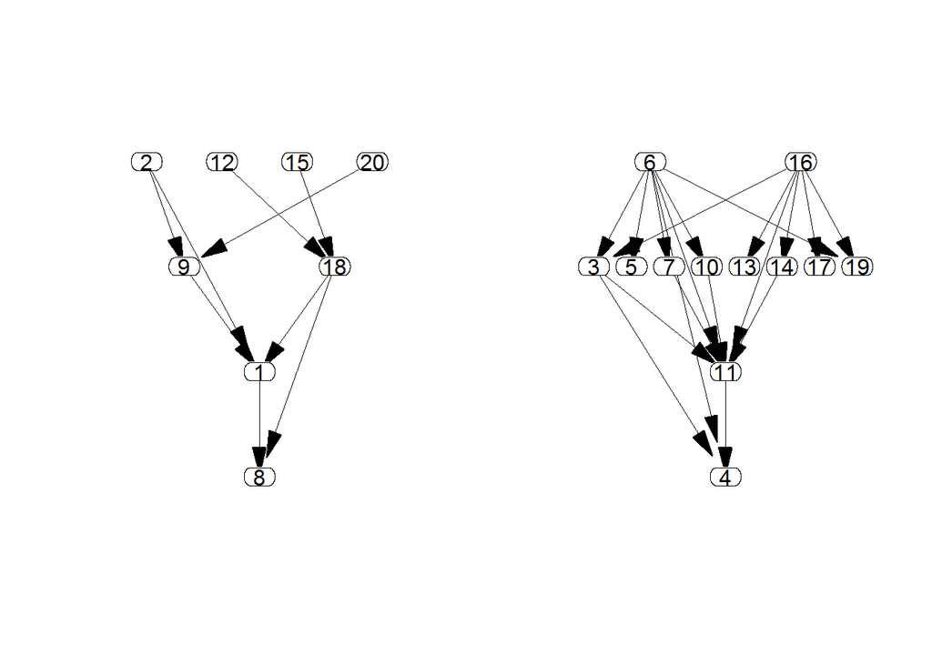

```r
po <- get.par("po", p)$value
# Only applicable to po generated by get.par()
viz(po)
```

# **8. What remains**

- The learning process for poks structure does not avoid loops. This makes the generating process after obtaining `po` cannot work properly.